# Contrastes de Restricciones

Carlos Jara

17 de enero de 2019

Para este tema utilizaremos la base correspondiente al ejercicio 3.1 del TP 4 continuando del html “Regresion Multiple - Analisis 2.0”

En este documento veremos diferentes procedimientos asociados a realizar hipotesis de tipo conjuntas (asociadas a varios coeficientes al mismo tiempo) de distinto tipo.

# 1 - Intervalo de confianza simultaneos

Hasta ahora hemos visto todo lo referido al calculo de los intervalos de confianza de cada uno de los estimadores, como calcularlos con diferentes niveles de confianza, que disitrbucion tienen los mismos y como interpretar los resultados hallados.

Puede darse la situacion que se presente el interes de analisis dos coeficientes en conjunto, esto lo vamos a realizar simplemente viendo un grafico donde se representa la elipse de los intervalos de confianza simultaneos.

Para nuestro ejemplo vamos a tomar los coeficientes estimados de “Precio” e “Ingreso” y vamos a ver las regiones de valores posibles a dos niveles de confianza, al 90% y al 99%.

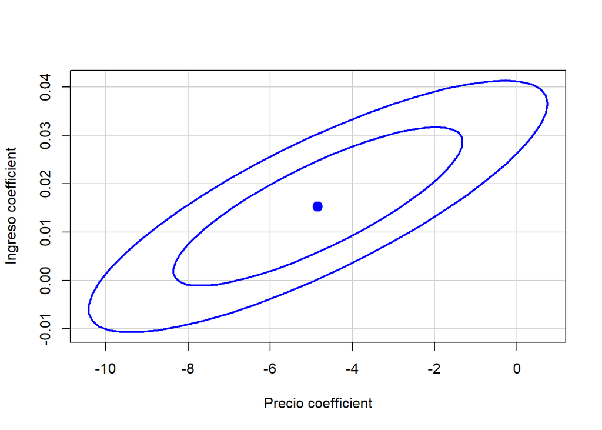

# 2 - Minimos Cuadrados Restringuidos

Fuente: Ender - Analisis Econometrico - pag 294

En ocasiones puede presentarse la necesidad de que los valores de los coeficientes no dependan estrictamente de los datos muestrales sino que *las estimaciones cumplan determinadas condiciones*, mas adelante se vera el caso especifico de la funcion de Cobb-Douglas.

En este caso, la forma de calcular los coeficientes presentan una diferencia desde el punto de vista matricial, esta diferencia esta dado por lo que se consideran *restricciones del modelo* que son ni mas ni menos que condiciones previas que les imponemos a los coeficientes.

Estas condiciones previas pueden ser restricciones de igualdad ej $\beta_{1}=0$ y restricciones de limitaciones, por ej $\beta_{1}+\beta_{2}=1$.

Para presentar un ejemplo, vamos a suponer que, los coeficientes de “Ingreso” y “Sustituto” deben sumar, entre ellos, 0.35.

La restriccion entonces esta dada por $\beta_{2}+\beta_{3}=0.35$

Para esto debemos armar la matriz R de restricciones y el vector r de los valores.

$R=[0~~0~~1~~1]$ que denota los coeficientes a restringuir. $r=0.35$ que denota el valor de los coeficientes.

Los coeficientes estimados se calcularan a traves de:
$$\hat{\beta_{r}}=\hat{\beta}-(X´X)^{-1}*R´*[R*(X´X)^{-1}*R´]^{-1}*(R\beta-r)$$
Y la matriz de Var-Cov de los estimadores estara dada por:
$$Var[\beta_{r}]=\hat{\sigma}^2*[(X´X)^{-1}-(X´X)^{-1}*R´*[R*(X´X)^{-1}*R´]^{-1}*R*(X´X)^{-1}]$$
Igualmente usaremos una funcion que permita calcular los coeficientes a partir de la restriccion.

[output not shown]

Ahora que tenemos los valores estimados de los coeficientes restringuidos, los comparamos con los valores hallados para el modelo “sin restricciones”

```
##
## Call:
## lm(formula = Demanda ~ ., data = demanda)
##
## Residuals:
##    Min     1Q Median     3Q    Max
## -6.836 -2.963 -0.563  2.810  7.300
##
## Coefficients:
##             Estimate Std. Error t value Pr(>|t|)
## (Intercept) 77.18462   16.80563    4.59  0.00077 ***
## Precio      -4.84175    1.47087   -3.29  0.00718 **
## Ingreso      0.01531    0.00685    2.23  0.04717 *
## Sustituto    0.30760    0.37159    0.83  0.42538
## ---
## Signif. codes:  0 '***' 0.001 '**' 0.01 '*' 0.05 '.' 0.1 ' ' 1
##
## Residual standard error: 4.41 on 11 degrees of freedom
## Multiple R-squared:  0.954,  Adjusted R-squared:  0.941
## F-statistic: 75.3 on 3 and 11 DF,  p-value: 1.29e-07
```

Otra forma de llegar al mismo resultado, es utilizando un paquete disponible de R que se llama “lmrest” de la cual utilizaremos la funcion “rls”

Para esta funcion, es necesario tres datos:

- R: los coeficientes a restringuir que deben cargarse como un vector fila.
- r: valor que deben asumir los coeficientes.
- delt: podemos calcularlo como $R \beta-r$.

```r
R
```

```
## [1] 0 0 1 1
```

```r
r
```

```
##      [,1]
## [1,] 0.35
```

Ahora vemos los coeficientes originales y el “delt”

```
##          [,1]
## [1,] 77.18462
## [2,] -4.84175
## [3,]  0.01531
## [4,]  0.30760
```

```
##          [,1]
## [1,] -0.02709
```

Ahora hacemos la estimacion bajo la restriccion planteada.

```
## $`*****Restricted Least Square Estimator*****`
##             Estimate Standard_error t_statistic pvalue
## (Intercept)  76.7143        15.5301       1.019   0.33
## Precio       -4.8166         1.4303          NA     NA
## Ingreso       0.0152         0.0067          NA     NA
## Sustituto     0.3348         0.0067          NA     NA
##
## $`*****Mean square error value******`
##   MSE
## 243.5
```

# 3 - Pruebas de Hipótesis Conjuntas

La tabla de coeficientes parciales analizada anteriormente posee entre sus columnas el valor del estadistico t y el pvalue asociada a la hipotesis nula que *el coeficiente es igual a cero*. Esta prueba tiene la relevancia de implicar, en caso de no rechazo, que *la variable independiente analizada no tiene relacion con la dependiente*.

Si bien esta prueba sale por defecto, depende la situacion y el modelo asociado, puede ser de interes hacer otras suposiciones respecto a las estimaciones.

A diferencia de los *Minimos Cuadrados Restringuidos* visto anteriormente, aqui se prueba una *restriccion* sobre los coeficientes estimados a traves de los datos de la muestra y no se hace una suposicion previa o restriccion respecto de alguna condicion que deben cumplir las estimaciones.

Se pueden hacer suposiciones de distinto tipo, similares a los Minimos Cuadrados Restringuidos.

- Suponer que un coeficiente toma *cualquier otro valor que no sea cero* Ej $H_{0})~~\beta_{1}=8$
- Suponer que varios coeficientes toman un valor especifico simultaneamente Ej Ej $H_{0})~~\beta_{1}=8~; \beta_{2}=2$

La primera opcion puede realizarse a traves de la prueba t conocida.  
La segunda opcion puede resolverse de dos maneras distintas pero solo vamos describir brevemente el procedimiento y obtener los resultados.

En funcion a plantear las hipotesis sobre los coeficientes y aplicarlos al modelo surge lo que se denomina el *modelo restringuido* este nuevo modelo surge de escribirlo en funcion a las restricciones y mediante simples trasnformaciones matematicas, eliminar estas restricciones. Ejemplo:

$Modelo \rightarrow~~\hat Y=b_{0}+b_{1}*x_{1}+b_{2}*x_{2}+b_{3}*x_{3}$

Si suponemos que $H_{0})~~\beta_{1}=8$, el *modelo restringuido* sera

$\hat Y=b_{0}+8*x_{1}+b_{2}*x_{2}+b_{3}*x_{3}$ $\Rightarrow$ $\hat Y-8*x_{1}=b_{0}+b_{2}*x_{2}+b_{3}*x_{3}$

Hallandose un nuevo modelo con valores “nuevos” de la variable dependiente y sin X1 que luego se compara, a traves de una prueba F con el modelo original o *modelo sin restringuir*, es estadistico F esta dado por:

$$F=\frac{(SCResiduos_{R}-SCResiduos_{SR})/q}{SCResiduos_{SR}/(n-k-1)}$$

siendo SR = sin restringuir; R = restringuido; q = cantidad de restricciones La esencia de la prueba es ver si existen diferencias es la SCResiduos entre el modelo resitrnguido y sin restringuir, si la variable es relevante, *existiran diferencias entre ambos modelos*.

La segunda opcion es el *estadistico de Wald* cuya ventaja es que no requiere el reescribir el modelo restringuido y la comparacion entre los modelos.

Otra ventaja del estadistico de Wald es que *si los residuos no se distribuyen normalmente, el estadistico F no posee distribucion F*. El estadistico de Wald sigue una distribucion chi cuadrado asintoticamente y puede reemplazar entonces a la F .(Greene p 245).

$W = \frac{(R\beta-r)^T*[R*(X^TX)*R´]*(R\beta-r)}{\hat\sigma^2}$ donde $W \sim \chi^2_{(j)}$ y $W/q~=~F_{q,n-k-1}$

Supongamos que se plantean las siguientes hipotesis, estan estan referidas a que todos los coeficientes, simultaneamente, son iguales a cero, esta es la llamada “Prueba Global” vista anteriormente.

$$H_{0})~\beta_{1}=\beta_{2}=\beta_{3}=0\Rightarrow H_{0})~R\beta=r \Rightarrow \left[\begin{array}{rrrr}0 & 1 & 0 &0 \\0 & 0 & 1 & 0 \\0 & 0 & 0 & 1\end{array}\right]~\left[\begin{array}{rrr}\beta_{1}\\ \beta_{2} \\ \beta_{3}\end{array}\right]~=\left[\begin{array}{rrr}0\\ 0 \\ 0\end{array}\right]$$
En este caso tenemos tres restricciones, una para cada $\beta$ donde la suposicion es que cada uno es cero.

Realizamos el test con la F y con la Chi para verificar la igualdad entre ellas. De acuerdo a lo visto, el estadistico F sera igual al Wald W / 3 y esto se verifica en ambas salidas.

```
## Linear hypothesis test
##
## Hypothesis:
## Precio = 0
## Ingreso = 0
## Sustituto = 0
##
## Model 1: restricted model
## Model 2: Demanda ~ Precio + Ingreso + Sustituto
##
##   Res.Df  RSS Df Sum of Sq    F  Pr(>F)
## 1     14 4600
## 2     11  214  3      4386 75.2 1.3e-07 ***
## ---
## Signif. codes:  0 '***' 0.001 '**' 0.01 '*' 0.05 '.' 0.1 ' ' 1
```

```
## Linear hypothesis test
##
## Hypothesis:
## Precio = 0
## Ingreso = 0
## Sustituto = 0
##
## Model 1: restricted model
## Model 2: Demanda ~ Precio + Ingreso + Sustituto
##
##   Res.Df  RSS Df Sum of Sq Chisq Pr(>Chisq)
## 1     14 4600
## 2     11  214  3      4386   226     <2e-16 ***
## ---
## Signif. codes:  0 '***' 0.001 '**' 0.01 '*' 0.05 '.' 0.1 ' ' 1
```

La hipotesis nula planteada es la prueba global y vemos que los resultados son identicos al estadistico F asociado a esta prueba y la igualdad entre F y Chi se cumple.

# 4 - Contrastes estadisticos anidados

Greene pag 263

Se denomina “contraste anidado” a las pruebas que se realizan de modelos alternativos al analizado, *donde estas alternativas representan un subconjunto de parametros del modelo original*, es decir, son modelos restringuidos como lo visto anteriormente.

En este caso, vamos utilizar los datos de un ejemplo del libro “Analisis Econometrico” de Greene 3ºEdicion pag 313 Tabla 7.8 sobre PBI y Consumo. El archivo se llama “contraste” y lo cambiamos a una serie de tiempo de datos anuales entre 1963 y 1982

| Año | Consumo | PBI | Consumo.1 | PBI.1 |
| --- | --- | --- | --- | --- |
| 1963 | 522.7 | 832.6 | 0.0 | 0.0 |
| 1964 | 550.4 | 876.3 | 522.7 | 832.6 |
| 1965 | 578.8 | 929.4 | 550.4 | 876.3 |
| 1966 | 605.9 | 984.9 | 578.8 | 929.4 |
| 1967 | 620.2 | 1011.4 | 605.9 | 984.9 |
| 1968 | 650.5 | 1058.2 | 620.2 | 1011.4 |
| 1969 | 670.5 | 1087.7 | 650.5 | 1058.2 |
| 1970 | 679.8 | 1085.5 | 670.5 | 1087.7 |
| 1971 | 700.1 | 1122.4 | 679.8 | 1085.5 |
| 1972 | 737.1 | 1185.9 | 700.1 | 1122.4 |
| 1973 | 767.9 | 1254.3 | 737.1 | 1185.9 |
| 1974 | 771.7 | 1246.3 | 767.9 | 1254.3 |
| 1975 | 776.2 | 1231.6 | 771.7 | 1246.3 |
| 1976 | 819.9 | 1298.2 | 776.2 | 1231.6 |
| 1977 | 860.0 | 1369.7 | 819.9 | 1298.2 |
| 1978 | 895.2 | 1438.6 | 860.0 | 1369.7 |
| 1979 | 922.3 | 1479.5 | 895.2 | 1438.6 |
| 1980 | 933.3 | 1474.0 | 922.3 | 1479.5 |
| 1981 | 942.8 | 1502.6 | 933.3 | 1474.0 |
| 1982 | 951.6 | 1475.4 | 942.8 | 1502.6 |

El modelo propuesto es el siguiente:

$$Consumo_{(t)}=\beta_{0}+\beta_{1}*PBI_{t}+\beta_{2}*Consumo_{t-1}+u_{t}$$
Realizamos la estimacion del modelo, sin la primera observacion debido a que tenemos a la variable consumo rezagada como una independiente y vemos la tabla ANOVA y de coeficientes parciales.

```
## Analysis of Variance Table
##
## Response: Consumo
##           Df Sum Sq Mean Sq F value  Pr(>F)
## PBI        1 307908  307908  6597.9 < 2e-16 ***
## Consumo.1  1    754     754    16.1 0.00099 ***
## Residuals 16    747      47
## ---
## Signif. codes:  0 '***' 0.001 '**' 0.01 '*' 0.05 '.' 0.1 ' ' 1
```

```
##
## Call:
## lm(formula = Consumo ~ PBI + Consumo.1, data = contraste[2:20,
##     ])
##
## Residuals:
##     Min      1Q  Median      3Q     Max
## -11.613  -3.772  -0.864   4.376  12.634
##
## Coefficients:
##             Estimate Std. Error t value Pr(>|t|)
## (Intercept)  -7.6915    11.4316   -0.67  0.51066
## PBI           0.4003     0.0626    6.39  8.9e-06 ***
## Consumo.1     0.3804     0.0947    4.02  0.00099 ***
## ---
## Signif. codes:  0 '***' 0.001 '**' 0.01 '*' 0.05 '.' 0.1 ' ' 1
##
## Residual standard error: 6.83 on 16 degrees of freedom
## Multiple R-squared:  0.998,  Adjusted R-squared:  0.997
## F-statistic: 3.31e+03 on 2 and 16 DF,  p-value: <2e-16
```

Planteemos ahora un segundo modelo, anidado respecto del primero, donde no utilizamos el Consumo en t-1, es decir el $\beta$ para el Consumo es igual a cero.

$$Consumo_{(t)}=\beta_{0}+\beta_{1}*PBI_{t}$$

Y vemos las mismas tablas para este modelo.

```
## Analysis of Variance Table
##
## Response: Consumo
##           Df Sum Sq Mean Sq F value Pr(>F)
## PBI        1 307908  307908    3489 <2e-16 ***
## Residuals 17   1500      88
## ---
## Signif. codes:  0 '***' 0.001 '**' 0.01 '*' 0.05 '.' 0.1 ' ' 1
```

```
##
## Call:
## lm(formula = Consumo ~ PBI, data = contraste[2:20, ])
##
## Residuals:
##    Min     1Q Median     3Q    Max
## -16.46  -6.31  -2.76   5.92  23.56
##
## Coefficients:
##             Estimate Std. Error t value Pr(>|t|)
## (Intercept)  -30.945     13.558   -2.28    0.036 *
## PBI            0.650      0.011   59.07   <2e-16 ***
## ---
## Signif. codes:  0 '***' 0.001 '**' 0.01 '*' 0.05 '.' 0.1 ' ' 1
##
## Residual standard error: 9.39 on 17 degrees of freedom
## Multiple R-squared:  0.995,  Adjusted R-squared:  0.995
## F-statistic: 3.49e+03 on 1 and 17 DF,  p-value: <2e-16
```

## Contraste F

El contraste F estara dado por

```
## Analysis of Variance Table
##
## Model 1: Consumo ~ PBI + Consumo.1
## Model 2: Consumo ~ PBI
##   Res.Df  RSS Df Sum of Sq    F  Pr(>F)
## 1     16  747
## 2     17 1500 -1      -754 16.1 0.00099 ***
## ---
## Signif. codes:  0 '***' 0.001 '**' 0.01 '*' 0.05 '.' 0.1 ' ' 1
```

## Contraste de Wald

Recordemos que el estadistico de Wald (W) esta dado por la siguiente igualdad $W = J * F$ siendo J la cantidad de restricciones y F el valor del estadistico F.

Si el modelo y las restricciones son lineales, entonces W puede calcularse como lo hemos visto. Si queremos comparar W con los otros estadisticos, deben corregirlo por los grados de libertad del CME, quedando W de la siguiente manera:

$$W=J*F*\frac{n}{n-k-1}$$

Dado que tenemos solo una restriccion, el estadistico W original deberia dar el mismo resultado.

```
## Wald test
##
## Model 1: Consumo ~ PBI + Consumo.1
## Model 2: Consumo ~ PBI
##   Res.Df Df    F  Pr(>F)
## 1     16
## 2     17 -1 16.1 0.00099 ***
## ---
## Signif. codes:  0 '***' 0.001 '**' 0.01 '*' 0.05 '.' 0.1 ' ' 1
```

```
## Wald test
##
## Model 1: Consumo ~ PBI + Consumo.1
## Model 2: Consumo ~ PBI
##   Res.Df Df Chisq Pr(>Chisq)
## 1     16
## 2     17 -1  16.1   0.000059 ***
## ---
## Signif. codes:  0 '***' 0.001 '**' 0.01 '*' 0.05 '.' 0.1 ' ' 1
```

Y el valor del W corregido seria

$$W=J*F*\frac{n}{n-k-1}\Rightarrow~W=1*16.15~*\frac{19}{16}\Rightarrow~W=19.1781$$

## Contraste de Razon de Verosimilitud

El contraste de razon de verosimilitud (LR) se realiza mediante la comparacion de los valores de la funcion de verosimilitud entre el modelo con y sin restricciones.

Al aplicar al logaritmo a una razon, el contraste queda como la resta entre el Logaritmo de la verosimilitud del modelo restringuido y el del modelo sin restringuir.

Dado que los valores son negativos, se toma el negativo y se lo incrementa por 2.

$$LR~=~-2[ln~L_{r}-ln~L_{sr}]~\sim~\chi_{(j)}$$

Tambien es posible calcular el LR a traves de las siguientes relaciones con la F y el W, en este caso, debemos utilizar el W corregido:

$$\begin{align}\large LR~&=n*ln(1+J*F/(n-k-1)_{sr})\\LR~&=n*ln(1+W/n)\end{align}$$

```
## Likelihood ratio test
##
## Model 1: Consumo ~ PBI + Consumo.1
## Model 2: Consumo ~ PBI
##   #Df LogLik Df Chisq Pr(>Chisq)
## 1   4  -61.8
## 2   3  -68.5 -1  13.3    0.00027 ***
## ---
## Signif. codes:  0 '***' 0.001 '**' 0.01 '*' 0.05 '.' 0.1 ' ' 1
```

$$LR~=~-2[ln~L_{r}-ln~L_{sr}]~\sim~\chi_{(j)}=-2*(-68.4652--61.8361)=13.26$$

Les dejo probar a ustedes el calculo basado en F y W corregido.

## Contraste del Multiplicador de Lagrange

El Multiplicador de Lagrange(LM) se basa en que la hipotesis nula planteada es valida, entonces en el estimador restringuido, las derivadas de la funcion del log de la verosimilitud tenderian a cero.

Las formulas expresan la relacion con el W corregido

- LM=$\frac{W}{1+W/n}$

Cuando las restricciones estan asociadas a todos los coeficientes del modelo, podemos usar tambien la siguiente formula y, en ambos caso, los valores del estadistico seran iguales.

- LM=n*$R^2$ siendo $R^2$ el coeficiente de Determinacion de la regresion sin restringuir.

# Contraste de Restricciones no anidadas

Greene pag 315

Aca la idea es las comparaciones entre dos modelos lineales alternativos que tratan de explicar la misma variable independiente (Y). Estos dos modelos alternativos que se presentan pueden contener en su formulacion un subconjunto identico de variables independientes y puede haber otro subconjunto de variables independientes diferentes entre si.

Como forma general podemos plantear lo siguiente:

$$H0)~y=~X\beta+e_{0}$$
$$H1)~y=~Z\gamma+e_{1}$$
Donde X y Z representan las variables independientes en cada modelo y $\beta$ y $\gamma$ representan los coeficientes asociados a las variables en cada modelo.

Las hipotesis planteadas permitirian definir cual de los modelos es mas apropiado para explicar la variable independiente, si rechazo H0, sera el segundo modelo, si no rechazo, sera el primero.

Vemos que ambas hipotesis son muy diferentes entre si lo que no permite escribir H1) como una restriccion de H0.

Vamos a utilizar los siguientes modelos para realizar las comparaciones

$$H_{0}=~C_{t}=\beta_{0}+\beta_{1}*PBI_{t}+\beta_{2}*PBI_{t-1}+e_{0}$$
$$H_{1}=~C_{t}=\gamma_{0}+\gamma_{1}*PBI_{t}+\gamma_{2}*Consumo_{t-1}+e_{1}$$

## Principio Global (encompassing test)

Partiendo del ultimo concepto de no poder escribir en forma de restriccion, este test *consiste en un anidamiento artificial de los modelos*.

$$y=\bar{X}\bar{\beta}+\bar{Z}\bar{\gamma}+W\delta+e$$

- $\bar{X}$= variables X que no estan en el segundo modelo.
- $\bar{Z}$= variables en Z que no estan en el primer modelo.
- W= variables que ambos modelos comparten en su formulacion.

Si las variables X explican totalmente a Y, los coeficientes $\gamma$ deberian ser cero al hacer la regresion aumentada y=X$\beta$+Z$\gamma$+e

Hacemos la prueba y vemos que ambos modelos son utiles en este caso.

```
## Encompassing test
##
## Model 1: Consumo ~ PBI + PBI.1
## Model 2: Consumo ~ PBI + Consumo.1
## Model E: Consumo ~ PBI + PBI.1 + Consumo.1
##           Res.Df Df    F  Pr(>F)
## M1 vs. ME     15 -1 27.1 0.00011 ***
## M2 vs. ME     15 -1 12.6 0.00296 **
## ---
## Signif. codes:  0 '***' 0.001 '**' 0.01 '*' 0.05 '.' 0.1 ' ' 1
```

## Contraste J

Este contraste se realiza con los siguientes pasos:

- Realizar las regresiones de ambos modelos y de cada uno se guarda los valores ajustados
- Se realiza una segunda regresion que incorpora a los modelos originales, *los valores ajustados del otro modelo*.

Si el coeficiente de la variable “ajustado” es significativo, indica que es preferible este.

```
## J test
##
## Model 1: Consumo ~ PBI + PBI.1
## Model 2: Consumo ~ PBI + Consumo.1
##                 Estimate Std. Error t value Pr(>|t|)
## M1 + fitted(M2)     2.74      0.528    5.20  0.00011 ***
## M2 + fitted(M1)    -2.70      0.763   -3.54  0.00296 **
## ---
## Signif. codes:  0 '***' 0.001 '**' 0.01 '*' 0.05 '.' 0.1 ' ' 1
```

## Contraste de Cox

Matematicamente complicado, el valor del estadistico tiene distribucion normal.

```
## Cox test
##
## Model 1: Consumo ~ PBI + PBI.1
## Model 2: Consumo ~ PBI + Consumo.1
##                 Estimate Std. Error z value Pr(>|z|)
## fitted(M1) ~ M2    -4.40       0.79   -5.57  2.6e-08 ***
## fitted(M2) ~ M1     2.85       1.30    2.20    0.028 *
## ---
## Signif. codes:  0 '***' 0.001 '**' 0.01 '*' 0.05 '.' 0.1 ' ' 1
```